# Lists (solutions)

## Primary exercises

1. *Create and investigate a list*.  
   Three students received different sets of grades (Amy: 1,6,7,9,10; Bob: 6,7,4,3,5,2,2,1,4; Dan: 9,9,10).  
   In a variable `scores` create a `list` (the names of the list elements should be the names of the students and the values should be the corresponding grades).  
   Print the list, its `class`, `length` and structure (`str`) of `scores`.

```r
scores <- list(
  Amy = c( 1,6,7,9,10 ),
  Bob = c( 6,7,4,3,5,2,2,1,4 ),
  Dan = c( 9,9,10 )
)
scores
```

```
$Amy
[1]  1  6  7  9 10

$Bob
[1] 6 7 4 3 5 2 2 1 4

$Dan
[1]  9  9 10
```

```r
class( scores )
```

```
[1] "list"
```

```r
length( scores )
```

```
[1] 3
```

```r
str( scores )
```

```
List of 3
 $ Amy: num [1:5] 1 6 7 9 10
 $ Bob: num [1:9] 6 7 4 3 5 2 2 1 4
 $ Dan: num [1:3] 9 9 10
```

2. *Add an element*, *change an element*.  
   Reuse `scores` from the previous exercise.  
   Add there grades for Eve (7,3,5,8,8,9) and print the list.  
   Then, for Dan merge new grades (8,8,6,7) with the existing grades (hint: use the combine function `c` to combine existing Dan’s grades with the new grades then put the result back to `scores`; do not type again `9,9,10`).

```r
scores[[ 'Eve' ]] <- c(7,3,5,8,8,9)
scores
```

```
$Amy
[1]  1  6  7  9 10

$Bob
[1] 6 7 4 3 5 2 2 1 4

$Dan
[1]  9  9 10

$Eve
[1] 7 3 5 8 8 9
```

```r
scores[[ "Dan" ]] <- c( scores[[ "Dan" ]], c(8,8,6,7) )
scores
```

```
$Amy
[1]  1  6  7  9 10

$Bob
[1] 6 7 4 3 5 2 2 1 4

$Dan
[1]  9  9 10  8  8  6  7

$Eve
[1] 7 3 5 8 8 9
```

3. *Single and double bracket operators*.  
   Reuse `scores` from the previous exercises.  
   Investigate the difference between `scores[[ "Bob" ]]` and `scores[ "Bob" ]`.  
   Look at what is printed and what is the class of each result.  
   Then compare `scores[[ c( "Amy", "Bob" ) ]]` with `scores[ c( "Amy", "Bob" ) ]`.  
   Understand, why the error is reported.

```r
scores[[ "Bob" ]]             # Returns the value of Bob element (vector)
```

```
[1] 6 7 4 3 5 2 2 1 4
```

```r
scores[ "Bob" ]               # Creates a new list with only Bob there (list)
```

```
$Bob
[1] 6 7 4 3 5 2 2 1 4
```

```r
class( scores[[ "Bob" ]] )
```

```
[1] "numeric"
```

```r
class( scores[ "Bob" ] )
```

```
[1] "list"
```

```r
scores[[ c( "Amy", "Bob" ) ]] # A list is needed to return two elements
```

```
Error in scores[[c("Amy", "Bob")]]: subscript out of bounds
```

```r
scores[ c( "Amy", "Bob" ) ]   # This creates a list, so many elements are ok
```

```
$Amy
[1]  1  6  7  9 10

$Bob
[1] 6 7 4 3 5 2 2 1 4
```

4. *Dollar operator*.  
   Reuse `scores` from the previous exercises.  
   Investigate the (lack of) difference between `scores$Bob` and `scores[[ "Bob" ]]`.  
   Look at what is printed and what is the class of each result.  
   Then compare `scores$Bo` with `scores[[ "Bo" ]]`.  
   Understand, why the `NULL` is returned.

```r
scores$Bob        # another way to access Bob
```

```
[1] 6 7 4 3 5 2 2 1 4
```

```r
scores[[ "Bob" ]] # get an element with exact name Bob
```

```
[1] 6 7 4 3 5 2 2 1 4
```

```r
class( scores$Bob )
```

```
[1] "numeric"
```

```r
class( scores[[ "Bob" ]] )
```

```
[1] "numeric"
```

```r
scores$Bo         # strange matching of names, it still finds Bob
```

```
[1] 6 7 4 3 5 2 2 1 4
```

```r
scores[[ "Bo" ]]  # there is no "Bo" so NULL is returned
```

[output not shown]

## Extra exercises

1. *A list returned by a function; test for association/correlation*.  
   For this exercise we need two random numerical vectors.  
   Let’s create `x` and `y`, each of 30 elements sampled from the normal distribution: `x <- rnorm( 30 )` and `y <- rnorm( 30 )`.  
   Print these vectors. You may also produce a scatter plot: `plot( x, y )`.  
   The function `cor.test` tests for association between corresponding elements of two vectors.  
   Use `h <- cor.test( x, y )` and print `h` to see a report of the association test.  
   Internally `h` is stored as a list. Print names of the elements stored in `h`.  
   Now, read `Help` for `cor.test`. In the section `Value` you will see the description of the `h` elements.  
   Get directy the values of elements `estimate` and `p.value`.

```r
x <- rnorm( 30 )
y <- rnorm( 30 )
x
```

```
 [1]  1.18101707 -0.76020458 -1.81607266  0.91524064  0.67399859 -0.06893562  1.47932074 -1.23422412 -1.51187550
[10]  0.87759343 -0.59003622  1.64528881 -1.37880804 -0.62959954 -0.66633242 -0.26783055  2.50412243 -0.71415713
[19] -0.82360790 -1.49836382 -0.53745425  0.32419095 -0.20373927  0.52119276  1.19194501  0.24953415  0.08888813
[28]  0.84041562  0.46996108  1.54824482
```

```r
y
```

```
 [1] -1.07022623  1.40980237  0.86312493  1.33811033  1.13502723  0.54178892  1.42213039 -0.29034649 -1.05388691
[10]  1.27748213 -1.26213839  0.85338223  1.55664040  0.07676056  0.40076620  0.24130164 -0.65189132  0.35266776
[19] -0.14038589  0.86826432  0.35971565  0.31079759 -0.74647382  0.11161653 -0.39472038 -0.52981581 -0.69597643
[28] -1.13877011 -0.10314710 -1.63249852
```

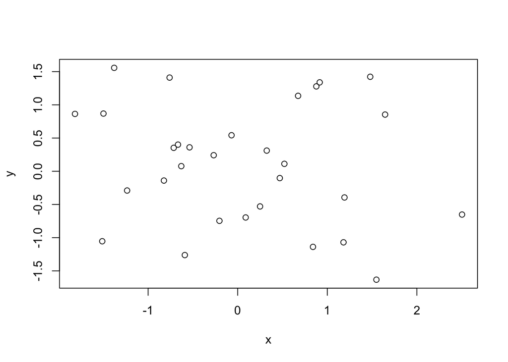

```r
plot( x, y )
```

```r
h <- cor.test( x, y )
h
```

```
    Pearson's product-moment correlation

data:  x and y
t = -0.84696, df = 28, p-value = 0.4042
alternative hypothesis: true correlation is not equal to 0
95 percent confidence interval:
 -0.4903951  0.2144298
sample estimates:
       cor
-0.1580491
```

```r
names( h )
```

```
[1] "statistic"   "parameter"   "p.value"     "estimate"    "null.value"  "alternative" "method"      "data.name"
[9] "conf.int"
```

```r
h[[ 'estimate' ]]
```

```
       cor
-0.1580491
```

```r
h[[ 'p.value' ]]
```

```
[1] 0.4041972
```

2. *A nested list*.  
   Let’s extend the concept of `scores` to describe various topics (see the code below).  
   Check `class` and `str` of `scores`.  
   Calculate how many students are in the `scores` list.  
   Get Dan’s scores in physics.

```r
scores <- list(
  Amy = list(
    math = c( 1,6,7,9,10 ),
    biology = c( 7,6,8 )
  ),
  Bob = list(
    math = c( 6,7,4,3,5,2,2,1,4 ),
    physics = c( 8,7 )
  ),
  Dan = list(
    math = c( 9,9,10 ),
    physics = c( 10, 10, 10 ),
    biology = c( 3, 5, 7 )
  )
)
```

```r
class( scores )
```

```
[1] "list"
```

```r
str( scores )
```

```
List of 3
 $ Amy:List of 2
  ..$ math   : num [1:5] 1 6 7 9 10
  ..$ biology: num [1:3] 7 6 8
 $ Bob:List of 2
  ..$ math   : num [1:9] 6 7 4 3 5 2 2 1 4
  ..$ physics: num [1:2] 8 7
 $ Dan:List of 3
  ..$ math   : num [1:3] 9 9 10
  ..$ physics: num [1:3] 10 10 10
  ..$ biology: num [1:3] 3 5 7
```

```r
length( scores )      # number of students
```

```
[1] 3
```

```r
length( scores$Bob )  # number of topics for which Bob has scores
```

```
[1] 2
```

```r
scores[[ "Dan" ]][[ "physics" ]]
```

```
[1] 10 10 10
```

```r
scores$Dan$physics
```

```
[1] 10 10 10
```

```r
scores$Dan[[ "physics" ]]
```

```
[1] 10 10 10
```

## Multitopic exercises

1. *(ADV) Split a table into list of tables by a column factor; merge back*.  
   Some functions might require an input to be provided as a list of tables.  
   Let’s assume that the `pulse` table should be split into a list of table parts based on the `exercise` argument.  
   Load the `pulse.csv` data to variable `pulse`.  
   Try `l <- pulse %>% split( .$exercise )` and investigate the `class`, `length` and `names` of the result `l`.  
   Use double square bracket to extract the part for `exercise` being `low`.  
   Finally, check that with `bind_rows` applied to `l` you can recreate the `pulse` table (but with a different order of rows).

```r
l <- pulse %>% split( .$exercise )  # . represents the object on the left side of %>%
class( l )
```

```
[1] "list"
```

```r
length( l )
```

```
[1] 3
```

```r
names( l )
```

```
[1] "high"     "low"      "moderate"
```

```r
l[[ "low" ]]
```

```
# A tibble: 37 x 13
   id     name      height weight   age gender smokes alcohol exercise ran   pulse1 pulse2  year
   <chr>  <chr>      <dbl>  <dbl> <dbl> <chr>  <chr>  <chr>   <chr>    <chr>  <dbl>  <dbl> <dbl>
 1 1993_E Lauri        173     64    18 female no     yes     low      sat       90     88  1993
 2 1993_F George       184     74    22 male   no     yes     low      ran       78    141  1993
 3 1993_L Frederick    178     58    19 male   no     no      low      sat       74     76  1993
 4 1993_P Mathew       185    110    22 male   no     yes     low      sat       77     73  1993
 5 1993_Q Leslie       170     56    19 male   no     no      low      sat       64     63  1993
 6 1993_U Jerome       175     60    19 male   no     no      low      sat       88     86  1993
 7 1993_V Arlene       140     50    34 female no     no      low      ran       70     98  1993
 8 1993_W Glenna       163     55    20 female no     no      low      sat       78     74  1993
 9 1995_B Olga         172     60    21 female no     no      low      sat       81     79  1995
10 1995_H Eliza        164     66    23 female no     no      low      ran       74    168  1995
# … with 27 more rows
```

```r
recreatedPulse <- bind_rows( l )
dim( pulse )
```

```
[1] 110  13
```

```r
dim( recreatedPulse )
```

```
[1] 110  13
```

2. *(ADV) Split a table by a column and write each part to a different file*.  
   Continue with the setup of the previous exercise.  
   Study/type/exectute the following example.  
   Find the newly created files in your filesystem.

```r
l <- pulse %>% split( .$exercise )
exercises <- names( l )                   # name in l of each table chunk
for( exercise in exercises ) {            # exercise will be a name of a single chunk
  fileName <- paste0( "pulse_", exercise, ".csv" )  # name of the file for the chunk
  message( "Writing file '", fileName, "'..." )
  write_csv( l[[ exercise ]], file = fileName )
}
```